# JianShuJiaoYou_2_Keywords_Word2Vec_t-SNE

继续更新出来本系列的代码：[乱炖数据之2700余篇“简书交友”专题文章数据的花式玩法](https://zhuanlan.zhihu.com/p/37618589)

代码见于 [**GitHub - DesertsX / JianShuJiaoYou**](https://github.com/DesertsX/JianShuJiaoYou)，下一篇也是本系列最后一篇会涉及文章的照片爬取、人脸识别及颜值打分和照片墙等更新后也会开源在此项目，欢迎star。

另外先预告下，之后打算开个**“Kaggle Kernel 学习系列”**，[GitHub - DesertsX / Kaggle-Kernel-Learning](https://github.com/DesertsX/Kaggle-Kernel-Learning)，主要是翻译和学习下kaggle上优秀的kernels。其中第一篇非常粗糙，还没润色、修改排版布局的notebook可供浏览下，也欢迎关注、star和提供宝贵建议：  
https://desertsx.github.io/2018/06/09/1_1_Start_Here-A_Gentle_Introduction/  
https://desertsx.github.io/2018/06/09/kaggle-Kernel-01/

# 关键词抽取

## 基于 TF-IDF 算法的关键词抽取

[fxsjy/jieba：结巴中文分词](https://github.com/fxsjy/jieba)  
`import jieba.analyse`

- jieba.analyse.extract_tags(sentence, topK=20, withWeight=False, allowPOS=())
  - sentence 为待提取的文本
  - topK 为返回几个 TF/IDF 权重最大的关键词，默认值为 20
  - withWeight 为是否一并返回关键词权重值，默认值为 False
  - allowPOS 仅包括指定词性的词，默认值为空，即不筛选

[百度云AI-词性缩略说明](https://cloud.baidu.com/doc/NLP/NLP-Python-SDK.html#.3C.CF.E9.5F.9C.E3.C3.45.DA.9C.9E.4C.F8.55.F1.E6)

[figure not shown]

```python
import pandas as pd
import jieba
import jieba.analyse
df12 = pd.read_csv('JianShuJiaoYou-All-Data.csv', encoding='utf-8')
content = df12.Artical_Content.values.tolist()
contents = "".join(content)
```

```python
print("  ".join(jieba.analyse.extract_tags(contents, topK=30, withWeight=False, allowPOS=())))
```

```
Building prefix dict from the default dictionary ...
Loading model from cache C:\Users\ADMINI~1\AppData\Local\Temp\jieba.cache
Loading model cost 2.690 seconds.
Prefix dict has been built succesfully.
```

```
喜欢  简书  自己  一个  我们  一起  可以  时候  没有  朋友  希望  知道  因为  文章  生活  觉得  就是  很多  什么  还是  交友  所以  如果  但是  真的  遇见  不是  现在  我会  文字
```

**Top200**  
allowPOS=('ns', 'n')

```python
textrank1 = "  ".join(jieba.analyse.extract_tags(contents, topK=200, withWeight=False, allowPOS=('ns', 'n')))
print(textrank1)
```

```
简书  时候  朋友  简友  文章  交友  我会  文字  故事  投稿  爱情  感觉  大家  大学  时间  专题  事情  人生  老师  树洞  世界  东西  同学  照片  地方  女生  电影  情书  性格  昵称  有点  交流  学校  梦想  内心  经历  时光  男生  作者  读书  城市  女孩  姑娘  孩子  单身  毕业  感情  凡人  青春  样子  名字  摄影  男朋友  校园  灵魂  父母  日子  对方  问题  学生  手机  朋友圈  小说  年龄  美食  专业  职业  评论  哥哥  心情  星座  女朋友  跑步  账号  素…
```

## 基于 TextRank 算法的关键词抽取

`jieba.analyse.textrank(sentence, topK=20, withWeight=False, allowPOS=('ns', 'n', 'vn', 'v'))`  
直接使用，接口相同，注意默认过滤词性。  
`jieba.analyse.TextRank()`  
新建自定义 TextRank 实例

基本思想:

- 将待抽取关键词的文本进行分词
- 以固定窗口大小(默认为5，通过span属性调整)，词之间的共现关系，构建图
- 计算图中节点的PageRank，注意是无向带权图

**Top20**  
allowPOS=('ns', 'n', 'vn', 'v')))

```python
textrank2 = "  ".join(jieba.analyse.textrank(contents, topK=20, withWeight=False, allowPOS=('ns', 'n', 'vn', 'v')))
print(textrank2)
```

```
喜欢  没有  时候  简书  生活  知道  希望  朋友  觉得  不会  文章  还有  开始  大家  时间  工作  文字  看到  可能  简友
```

**Top200**  
allowPOS=('ns', 'n')

```python
textrank3 = "  ".join(jieba.analyse.textrank(contents, topK=200, withWeight=False, allowPOS=('ns', 'n')))
print(textrank3)
```

```
时候  简书  朋友  文章  大家  交友  时间  大学  文字  故事  简友  感觉  老师  我会  爱情  学校  专题  世界  职业  人生  投稿  电影  地方  有点  作者  城市  东西  同学  学生  树洞  地点  经历  事情  照片  读书  孩子  问题  专业  毕业  性格  姑娘  北京  校园  交流  小说  昵称  女生  上海  摄影  手机  内心  女孩  中国  个人  梦想  星座  父母  名字  男生  音乐  青春  年龄  家乡  时光  感情  文学  对方  文化  样子  无法  公司  美丽  素材  文艺  社会  …
```

**Top200**  
allowPOS=('ns', 'n')并返回关键词权重值

```python
textrank4 = jieba.analyse.textrank(contents, topK=200, withWeight=True, allowPOS=('ns', 'n'))
textrank4
```

```
Building prefix dict from the default dictionary ...
Loading model from cache C:\Users\ADMINI~1\AppData\Local\Temp\jieba.cache
Loading model cost 3.024 seconds.
Prefix dict has been built succesfully.
```

```
[('时候', 1.0),
 ('简书', 0.9286492277441794),
 ('朋友', 0.5604058706337074),
 ('文章', 0.5119472310224017),
 ('大家', 0.4435913680744001),
 ('交友', 0.4205067493937958),
 ('时间', 0.41736915018165616),
 ('大学', 0.4169278527224929),
 ('文字', 0.3963519612404718),
 ('故事', 0.3672191429321304),
 ('简友', 0.36709289668920975),
 ('感觉', 0.35411529061992564),
 ('老师', 0.3370038815808798),
 ('我会', 0.3101842556848121),
 ('爱情', 0.30825849431508767),
 ('学校', 0.30662500150442545),
 ('专题', 0.299080272407531),
 ('世界', 0.29379547283412577),
 ('职业', 0.2929284746124939),
 ('人生', 0.28212943657396355),
 ('投稿', 0.2754165402924258),
 ('电影', 0.27084013365232207),
 ('地方', 0.2655583424411362),
 ('有点', 0.2649051503775889),
 ('作者', 0.2613174610146301),
 ('城市', 0.24550688949342553),
 ('东西', 0.24348419679662475),
 ('同学', 0.23841170153880684),
 ('学生', 0.23443411939906686),
 ('树洞', 0.22549473477170823),
 ('地点', 0.20712676215703693),
 ('经历', 0.20608419109008802),
 ('事情', 0.20498750024362533),
 ('照片', 0.19831572966462627),
 ('读书', 0.19723125271747666),
 ('孩子', 0.19590875756904957),
 ('问题', 0.1950987501036272),
 ('专业', 0.1941308404236128),
 ('毕业', 0.1939784822425237),
 ('性格', 0.19163281061909265),
```

[output cut: 145 more lines]

```
 ('陪伴', 0.054031257633965254),
 ('情绪', 0.05394182531653573),
 ('人家', 0.05381915110012886),
 ('意义', 0.0536712199874301),
 ('室友', 0.0536620359988344),
 ('大学生', 0.053617265404430264),
 ('国家', 0.05351253423804434),
 ('女孩子', 0.05346623748374888),
 ('山东', 0.05332188488298575),
 ('状态', 0.053309158881276124),
 ('程序员', 0.053049965125002145),
 ('天空', 0.05282982480780842),
 ('链接', 0.052685644517004276),
 ('思维', 0.05252223966685003),
 ('标准', 0.05250929737688007)]
```

**上述几步都蛮耗时，可以手动将关键词抽取结果拿出来，方便后续步骤直接用**

```python
textrank4 = [('时候', 1.0), ('简书', 0.9286492277441794), ('朋友', 0.5604058706337074), ('文章', 0.5119472310224017), ('大家', 0.4435913680744001), ('交友', 0.4205067493937958), ('时间', 0.41736915018165616), ('大学', 0.4169278527224929), ('文字', 0.3963519612404718), ('故事', 0.3672191429321304), ('简友', 0.36709289668920975), ('感觉', 0.35411529061992564), ('老师', 0.3370038815808798), ('我会', 0.3101842556848121), ('爱情', 0.30825849431508767), ('学校', 0.30662500150442545), ('专题', 0.299080272407531), ('世界', 0.29379547283412577), ('职业', 0.2929284746124939), ('人生', 0.28212943657396355), ('投稿', 0.2754165402924258), ('电影', 0.27084013365232207), ('地方', 0.2655583424411362), ('有点', 0.2649051503775889), ('作者', 0.2613174610146301), ('城市', 0.24550688949342553), ('东西', 0.24348419679662475), ('同学', 0.23841170153880684), ('学生', 0.23443411939906686), ('树洞', 0.22549473477170823), ('地点', 0.20712676215703693), ('经历', 0.20608419109008802), ('事情', 0.20498750024362533), ('照片', 0.19831572966462627), ('读书', 0.19723125271747666), ('孩子', 0.19590875756904957), ('问题', 0.1950987501036272), ('专业', 0.1941308404236128), ('毕业', 0.1939784822425237), ('性格', 0.19163281061909265), ('姑娘', 0.1872873953553624), ('北京', 0.18711323544187944), ('校园', 0.18108048763244047), ('交流', 0.17479075171098915), ('小说', 0.1744489125132006), ('昵称', 0.17278550504553727), ('女生', 0.16036058073353426), ('上海', 0.1555424366485686), ('摄影', 0.15437243518224159), ('手机', 0.15001221722155475), ('内心', 0.1498803581932257), ('女孩', 0.1420033316012718), ('中国', 0.14108442073599178),('个人', 0.1396337218826528), ('梦想', 0.1383044717425788), ('星座', 0.13691646574539962), ('父母', 0.13591526696869471), ('名字', 0.13546880519692672), ('男生', 0.1351786737272621), ('音乐', 0.13261750151949542), ('青春', 0.13248117530194672), ('年龄', 0.130218163157079), ('家乡', 0.13015312193689477), ('时光', 0.13011176820620574), ('感情', 0.1236245579291077), ('文学', 0.12219078262090802), ('对方', 0.12127366033704323), ('文化', 0.11949249561938287), ('样子', 0.11933270991118002), ('无法', 0.1160694694481027), ('公司', 0.11393609119202278), ('美丽', 0.11346685727914173), ('素材', 0.11260943797689577), ('文艺', 0.11214607732254779), ('社会', 0.11129040508307939), ('记录', 0.11026878566857379), ('哥哥', 0.10647851040624062), ('灵魂', 0.10550214627239118), ('妈妈', 0.10548042030212171), ('单身', 0.10441633340095628), ('美食', 0.10353294903694504), ('日子', 0.10329149448243866), ('家庭', 0.10318263761013736), ('回家', 0.1031507187785797), ('情书', 0.1016292107348871), ('平台', 0.10033539429082454), ('心情', 0.09941978518090189), ('关系', 0.09936235890745156), ('结果', 0.09921749317216594),('性别', 0.09774431497611233), ('原因', 0.09718288385610466), ('能力', 0.09654204453652812), ('眼睛', 0.09500589276815452), ('方面', 0.09344377276647843), ('咖啡', 0.09308300266400003), ('编辑', 0.09261718849186786), ('唱歌', 0.09259885920867623), ('游戏', 0.0925207868456076), ('评论', 0.09215243824369766), ('小时', 0.0902800089476482), ('现实', 0.08990953691346824), ('画画', 0.08934110877054963), ('声音', 0.08825729924787094), ('小时候', 0.08822176014621334), ('历史', 0.08809857794598301), ('姐姐', 0.08792537493674343), ('情感', 0.08792207096319951), ('理想', 0.08771235173748758), ('方式', 0.08724940148031382), ('跑步', 0.0869304779180642), ('男人', 0.08633249891743755), ('想象', 0.0861780084107231), ('凡人', 0.08472430195238598), ('图书馆', 0.08379652187244854), ('内容', 0.08369840352278336), ('时代', 0.08357829612162883), ('见面', 0.08268384574649262), ('大赛', 0.08214344765516189), ('身体', 0.08072503997603832), ('衣服', 0.08013296305558819), ('宿舍', 0.08007039566913592), ('嘉宾', 0.07976389314399422), ('女人', 0.07880340512675509), ('总会', 0.07857359333429292), ('公众', 0.07788072785387959), ('风景', 0.07728373398381409), ('学会', 0.07620797483354486), ('陌生', 0.07554458794593061), ('兴趣', 0.07547524059813622), ('基本', 0.07511660271898915), ('学历', 0.07466066268179476), ('精神', 0.07320609402769758), ('成都', 0.07209550659981127), ('先生', 0.07159410516959858), ('好友', 0.07086173707576542), ('校友', 0.0706236976907227), ('习惯', 0.07036667551986377), ('作品', 0.070225897406981), ('教室', 0.07003924798119593), ('艺术', 0.06953458309960944), ('思想', 0.0695151939250779), ('小学', 0.06878776810395813), ('男朋友', 0.06834683897785196), ('线下', 0.06822167039165473), ('联系', 0.06778415729076948), ('社群', 0.06652535382709325), ('武汉', 0.06640180937345067), ('家人', 0.06622742726001085), ('信息', 0.06599559275698536), ('模样', 0.06583275269266327), ('礼物', 0.0654869832982491), ('世间', 0.06544861340496239), ('长大', 0.0651926779186585), ('味道', 0.06507163406682973), ('陌生人', 0.06479192726379385), ('广州', 0.06474913624114682), ('父亲', 0.06443876952462216), ('朋友圈', 0.06358797412193237), ('印象', 0.06348968764072996), ('机会', 0.06305097363139245), ('女性', 0.06259522220057501), ('体重', 0.0622019187477037), ('空间', 0.06146234707401598), ('妹子', 0.06075048517571015), ('玫瑰', 0.060599050346646754), ('记忆', 0.06048688933848081), ('婚姻', 0.06007535032378195), ('人们', 0.06002079239154834), ('重庆', 0.05990200188329886), ('热情', 0.059740919682304196), ('杭州', 0.05951863279283471), ('计划', 0.05848635158026506),('情况', 0.05841156001822765), ('读者', 0.05837196888897777), ('男孩', 0.05832264782248742), ('西安', 0.056978015411144875), ('小伙伴', 0.05650381835027717), ('励志', 0.05624269204664784), ('会员', 0.0561974154919452), ('少女', 0.055158999699954095), ('火车', 0.05452389418507691), ('体验', 0.054505113215031285), ('深圳', 0.05447157828333691), ('幻想', 0.05444464616366215), ('人物', 0.05416593678569893), ('陪伴', 0.054031257633965254), ('情绪', 0.05394182531653573), ('人家', 0.05381915110012886), ('意义', 0.0536712199874301), ('室友', 0.0536620359988344), ('大学生', 0.053617265404430264), ('国家', 0.05351253423804434), ('女孩子', 0.05346623748374888), ('山东', 0.05332188488298575), ('状态', 0.053309158881276124), ('程序员', 0.053049965125002145), ('天空', 0.05282982480780842), ('链接', 0.052685644517004276), ('思维', 0.05252223966685003), ('标准', 0.05250929737688007)]
```

抽取出这些关键词后，突然想到可以使用word2vec词向量，看看**这些词语在向量空间中会是怎样分布的？哪些词语会在相似的区域？**

原本想用`gensim库`自己训练word2vec，但是没成功（后面重新研究了下，已经搞定了，后面再介绍），机缘巧合接触到百度云的产品，于是调用下看看效果如何。

# Word2Vec 词向量

词向量，就是将词语映射成一个固定维度的向量。词向量可能具备一定的语义信息，如相似的词语在相近的向量空间（如西瓜和苹果都属于水果，但苹果也存在歧义）；可以学到词语之间的关系，如经典的“男人-女人=国王-王后”（[**King – Man + Woman = Queen**](https://blog.acolyer.org/2016/04/21/the-amazing-power-of-word-vectors/)）。

又比如，[国家与首都之间的对应关系也能通过词向量反映出来](https://deeplearning4j.org/word2vec)。后文也调用百度云的api试了一下几组词，有类似效果。

[figure not shown]

相关原理可自行了解，文本不展开了：

- [NLP - 秒懂词向量Word2vec的本质](https://zhuanlan.zhihu.com/p/26306795)
- [无痛理解word2vec](https://zhuanlan.zhihu.com/p/35500923)
- [自然语言处理（NLP）基础概念（一）：词向量（word vector）及其生成方法介绍](https://zhuanlan.zhihu.com/p/28839243)  
  [The amazing power of word vectors](https://blog.acolyer.org/2016/04/21/the-amazing-power-of-word-vectors/)

## [百度云NLP-词向量表示](https://cloud.baidu.com/product/nlp/word_embedding)

再贴下官网的解释：

- 词向量计算是通过训练的方法，将语言词表中的词映射成一个长度固定的向量。词表中所有的词向量构成一个向量空间，每一个词都是这个词向量空间中的一个点，利用这种方法，实现文本的可计算。

[figure not shown]

先官网注册下以便调用API，再按照Python库：`pip install baidu-aip`。

```python
# 自然语言处理
# pip install baidu-aip
# https://cloud.baidu.com/doc/NLP/NLP-Python-SDK.html#.E6.96.B0.E5.BB.BAAipNlp

# 新建一个AipNlp
from aip import AipNlp

""" 你的 APP_ID/API_KEY/SECRET_KEY  """
APP_ID = '你的 APP_ID'
API_KEY = '你的 API_KEY'
SECRET_KEY = 'SECRET_KEY'
client = AipNlp(APP_ID, API_KEY, SECRET_KEY)
```

**示例：调用词法分析**

```python
text = "百度是一家高科技公司"

""" 调用词法分析 """
t = client.lexer(text);
t
```

```
{'items': [{'basic_words': ['百度'],
   'byte_length': 4,
   'byte_offset': 0,
   'formal': '',
   'item': '百度',
   'loc_details': [],
   'ne': 'ORG',
   'pos': '',
   'uri': ''},
  {'basic_words': ['是'],
   'byte_length': 2,
   'byte_offset': 4,
   'formal': '',
   'item': '是',
   'loc_details': [],
   'ne': '',
   'pos': 'v',
   'uri': ''},
  {'basic_words': ['一', '家'],
   'byte_length': 4,
   'byte_offset': 6,
   'formal': '',
   'item': '一家',
   'loc_details': [],
   'ne': '',
   'pos': 'm',
   'uri': ''},
  {'basic_words': ['高', '科技'],
   'byte_length': 6,
   'byte_offset': 10,
   'formal': '',
   'item': '高科技',
   'loc_details': [],
   'ne': '',
   'pos': 'n',
   'uri': ''},
  {'basic_words': ['公司'],
   'byte_length': 4,
   'byte_offset': 16,
   'formal': '',
   'item': '公司',
   'loc_details': [],
   'ne': '',
   'pos': 'n',
   'uri': ''}],
 'log_id': 8801307671095477679,
 'text': '百度是一家高科技公司'}
```

**示例：调用词向量表示**  
每个词语用1024维的词向量表示

```python
word = "张飞"

""" 调用词向量表示 """
w = client.wordEmbedding(word);
w
```

```
{'log_id': 8675519369623945866,
 'vec': [-0.290384,
  -0.276273,
  0.302719,
  0.7209,
  0.108958,
  0.553115,
  -0.0877021,
  0.359806,
  0.0880146,
  -0.189588,
  0.244222,
  -0.0651301,
  0.0638421,
  0.533272,
  -0.00821664,
  0.0375696,
  -0.327892,
  -0.46532,
  0.865607,
  0.623493,
  -0.178252,
  -0.0400714,
  0.25975,
  0.11109,
  0.0953429,
  0.101911,
  -0.535927,
  -0.0933478,
  0.601825,
  -0.321298,
  0.631975,
  0.0875886,
  0.870735,
  -0.269735,
  -0.585102,
  0.319081,
  0.184684,
  -0.720537,
  -0.383718,
```

[output cut: 948 more lines]

```
  -0.422333,
  -0.146097,
  0.520181,
  0.0972754,
  -0.186103,
  -0.0766742,
  -0.745162,
  0.364611,
  0.186148,
  -0.250859,
  0.243429,
  -0.251991,
  -0.424686,
  ...],
 'word': '张飞'}
```

```python
print(w['word'], len(w['vec']),'\n', w['vec'])
```

```
张飞 1024
 [-0.290384, -0.276273, 0.302719, 0.7209, 0.108958, 0.553115, -0.0877021, 0.359806, 0.0880146, -0.189588, 0.244222, -0.0651301, 0.0638421, 0.533272, -0.00821664, 0.0375696, -0.327892, -0.46532, 0.865607, 0.623493, -0.178252, -0.0400714, 0.25975, 0.11109, 0.0953429, 0.101911, -0.535927, -0.0933478, 0…
```

### 获取textrank4中Top200词语的词向量

除掉词库中不含的词语外，还有187个词语。

```python
import numpy as np
words_list = []
word_vectors = []
for word,_ in textrank4:
    try:
        data = client.wordEmbedding(word)
        word_vector = data['vec']
        #print(data['word'])
        words_list.append(data['word'])
        word_vectors.append(word_vector)
    except:
        print("No word:{}".format(word))

word_vectors = np.array(word_vectors)
# print("Total words:", len(words_list))  # 200
print(words_list)
print("Total words:", len(words_list), '\tWord Embedding shapes:', word_vectors.shape)
# Total words: 187
# Word Embedding shapes: (187, 1024)
```

```
No word:简书
No word:简友
No word:有点
No word:小时候
No word:图书馆
No word:男朋友
No word:线下
No word:陌生人
No word:朋友圈
No word:小伙伴
No word:大学生
No word:女孩子
No word:程序员
['时候', '朋友', '文章', '大家', '交友', '时间', '大学', '文字', '故事', '感觉', '老师', '我会', '爱情', '学校', '专题', '世界', '职业', '人生', '投稿', '电影', '地方', '作者', '城市', '东西', '同学', '学生', '树洞', '地点', '经历', '事情', '照片', '读书', '孩子', '问题', '专业', '毕业', '性格', '姑娘', '北京', '校园', '交流', '小说', '昵称', '女生', '上海', '摄影', '手机', '内心', '女孩', '中国',…
Total words: 187 	Word Embedding shapes: (187, 1024)
```

## t-SNE 可视化高维数据

t-SNE 可用来可视化高维数据。每个词语的词向量有1024维，因而分别在2维和3维下查看下效果。 [sklearn.manifold.TSNE](http://scikit-learn.org/stable/modules/generated/sklearn.manifold.TSNE.html)

### t-SNE 2维

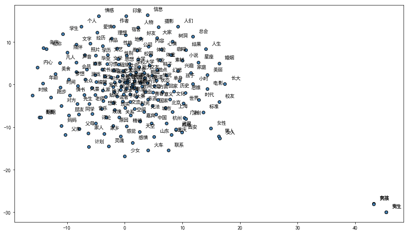

```python
import matplotlib.pyplot as plt
plt.rcParams['font.sans-serif']=['SimHei'] # 用来正常显示中文标签
plt.rcParams['axes.unicode_minus']=False # 用来正常显示负号
%matplotlib inline
#%config InlineBackend.figure_format='svg'

from sklearn.manifold import TSNE

def plot_tsne_2D(word_vectors, words_list):
    tsne = TSNE(n_components=2, random_state=0, n_iter=10000, perplexity=3)
    np.set_printoptions(suppress=True)
    T = tsne.fit_transform(word_vectors)
    labels = words_list

    plt.figure(figsize=(14, 10))
    plt.scatter(T[:,0], T[:,1], c='steelblue', edgecolors='k')
    for label, x, y in zip(labels, T[:,0], T[:,1]):
        plt.annotate(label, xy=(x+1, y+1),xytext=(0,0), textcoords='offset points')

plot_tsne_2D(word_vectors, words_list)
```

### t-SNE 3维

虽然比后面调用主成分分析（PCA）的降维结果要好些，但还是很杂乱，并没有看到相关的、相似的词语在相近区域。尤其是“哥哥”、“姐姐”、“女人”、“女孩”、“孩子”之类词语分布的很分散，感觉是不是哪里出了问题？懂的小伙伴还望指教！

[figure not shown]

```python
# https://stackoverflow.com/questions/10374930/matplotlib-annotating-a-3d-scatter-plot
from mpl_toolkits.mplot3d import Axes3D

def plot_tsne_3D(word_vectors, words_list):
    tsne = TSNE(n_components=3, random_state=0, n_iter=10000, perplexity=2)
    np.set_printoptions(suppress=True)
    T = tsne.fit_transform(word_vectors)
    labels = words_list

    plt.figure(figsize=(14, 12))
    ax = plt.subplot(111,projection='3d')

    for i in range(len(T)): # plot each point + it's index as text above
        x = T[i,0]
        y = T[i,1]
        z = T[i,2]
        label = labels[i]
        ax.scatter(x, y, z, color='b');
        ax.text(x, y, z, '%s' % (label), size=9, zorder=1, color='k');

    ax.set_title('word2vec t-SNE 3D');
    ax.set_xlabel('x');
    ax.set_ylabel('y');
    ax.set_zlabel('z');

plot_tsne_3D(word_vectors, words_list)
```

### PCA 降维

效果不如t-SNE。弃之

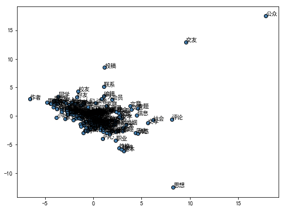

```python
#%config InlineBackend.figure_format='svg'

from sklearn.decomposition import PCA

pca = PCA(n_components=2, random_state=0)
pcs = pca.fit_transform(word_vectors)
labels = words_list

plt.figure(figsize=(8,6))

for i in range(len(labels)):
    label = labels[i]
    x, y =pcs[i]
    plt.scatter(x, y , c='steelblue', edgecolors='k')
    # xy=(x+1, y+1)
    plt.annotate(label, xy=(x+1e-4, y+1e-3), xytext=(0,0), textcoords='offset points')
```

```python
# plt.savefig('word2vec_t-SNE_3D_svg.pdf', bbox_inches='tight')
# plt.show()
```

### 复现下官网的例子

由于上述词向量可视化的结果似乎不太理想，为了探索下到底哪出了问题，于是想到看看能不能复现出官网里配图的效果。当然一开始并不清楚它是举例用，随便画的，还是实际通过计算后绘制的。个人倾向于后者，那么应该是能复现吧？！

[figure not shown]

将获取词向量，2维、3维 t-SNE 可视化均写出函数，方便后面重复使用，重复摸索。

```python
import numpy as np
from aip import AipNlp

""" 你的 APP_ID/API_KEY/SECRET_KEY """
APP_ID = '11338151'
API_KEY = '4sGR40BaZtoicHWrV91S2aoS'
SECRET_KEY = 'BrQ3jj7HkaRht69aKjFkdlhXoEtLbEiF'
client = AipNlp(APP_ID, API_KEY, SECRET_KEY)

words = ['姨夫', '老公', '妹妹', '奶奶', '表哥', '干爸', '外爷', '继父',
 '性感', '沮丧', '真够', '悲愤', '探询', '怀想', '甜美',
 '南宁', '合肥', '淮海', '珠江', '津蒙', '奎河', '邕江', '滦河']

def get_word2vec(words):
    words_list = []
    word_vectors = []
    for word in words:
        try:
            data = client.wordEmbedding(word)
            word_vector = data['vec']
            #print(data['word'])
            words_list.append(data['word'])
            word_vectors.append(word_vector)
        except:
            print("No word:{}".format(word))

    word_vectors = np.array(word_vectors)
    print(words_list)
    print("Total words:", len(words_list), '\tWord Embedding shapes:', word_vectors.shape)
    return word_vectors, words_list

word_vectors, words_list = get_word2vec(words)
```

```
['姨夫', '老公', '妹妹', '奶奶', '表哥', '干爸', '外爷', '继父', '性感', '沮丧', '真够', '悲愤', '探询', '怀想', '甜美', '南宁', '合肥', '淮海', '珠江', '津蒙', '奎河', '邕江', '滦河']
Total words: 23 	Word Embedding shapes: (23, 1024)
```

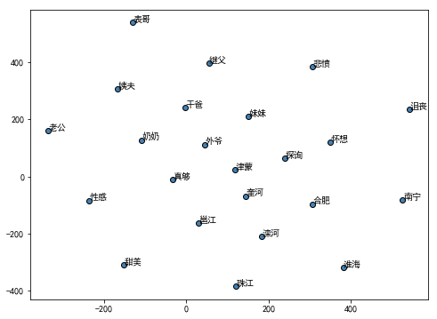

```python
import matplotlib.pyplot as plt
plt.rcParams['font.sans-serif']=['SimHei'] # 用来正常显示中文标签
plt.rcParams['axes.unicode_minus']=False # 用来正常显示负号
%matplotlib inline
#%config InlineBackend.figure_format='svg'

from sklearn.manifold import TSNE

def plot_tsne_2D(word_vectors, words_list):
    tsne = TSNE(n_components=2, random_state=0, n_iter=10000, perplexity=3)
    np.set_printoptions(suppress=True)
    T = tsne.fit_transform(word_vectors)
    labels = words_list

    plt.figure(figsize=(8, 6))
    plt.scatter(T[:,0], T[:,1], c='steelblue', edgecolors='k')
    for label, x, y in zip(labels, T[:,0], T[:,1]):
        plt.annotate(label, xy=(x+1, y+1),xytext=(0,0), textcoords='offset points')

plot_tsne_2D(word_vectors, words_list)
```

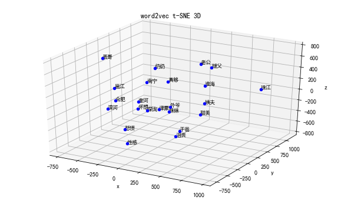

```python
# https://stackoverflow.com/questions/10374930/matplotlib-annotating-a-3d-scatter-plot
from mpl_toolkits.mplot3d import Axes3D

def plot_tsne_3D(word_vectors, words_list):
    tsne = TSNE(n_components=3, random_state=0, n_iter=10000, perplexity=2)
    np.set_printoptions(suppress=True)
    T = tsne.fit_transform(word_vectors)
    labels = words_list

    plt.figure(figsize=(10, 6))
    ax = plt.subplot(111,projection='3d')

    for i in range(len(T)): # plot each point + it's index as text above
        x = T[i,0]
        y = T[i,1]
        z = T[i,2]
        label = labels[i]
        ax.scatter(x, y, z, color='b');
        ax.text(x, y, z, '%s' % (label), size=9, zorder=1, color='k');

    ax.set_title('word2vec t-SNE 3D');
    ax.set_xlabel('x');
    ax.set_ylabel('y');
    ax.set_zlabel('z');

plot_tsne_3D(word_vectors, words_list)
```

**完全摸不着头脑，可能是需要继续调参吧？？？**

### Try Again: 想些词再试试

自己不死心的，又想了三类词语，这回的效果理想了很多。不过“腾讯”一词有些突兀，于是去掉后再试试。

```
['中国', '北京', '日本', '东京', '法国', '巴黎', '俄罗斯', '莫斯科', '百度', '李彦宏', '京东', '刘强东', '腾讯', '马化腾', '阿里巴巴', '马云', '三国', '曹操', '刘备', '西游记', '唐僧', '悟空', '红楼', '宝玉', '黛玉', '王熙凤']
Total words: 26 	Word Embedding shapes: (26, 1024)
```

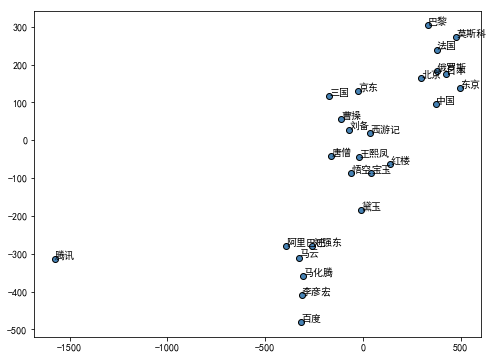

```python
words = ['中国', '北京', '日本', '东京', '法国', '巴黎', '俄罗斯', '莫斯科',
 '百度', '李彦宏', '京东', '刘强东', '腾讯', '马化腾', '阿里巴巴','马云',
 '三国', '曹操', '刘备', '西游记', '唐僧', '悟空', '红楼', '宝玉', '黛玉','王熙凤']

word_vectors, words_list = get_word2vec(words)
plot_tsne_2D(word_vectors, words_list)
```

**去掉“腾讯”一词后，除了“京东”一词明显突兀，其他都还不错，相似相关的词分布在了一起**

```
['中国', '北京', '日本', '东京', '法国', '巴黎', '俄罗斯', '莫斯科', '百度', '李彦宏', '京东', '刘强东', '马化腾', '阿里巴巴', '马云', '三国', '曹操', '刘备', '西游记', '唐僧', '悟空', '红楼', '宝玉', '黛玉', '王熙凤']
Total words: 25 	Word Embedding shapes: (25, 1024)
```

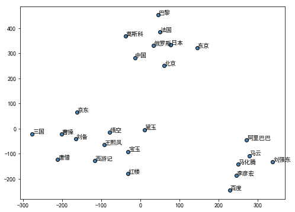

```python
words = ['中国', '北京', '日本', '东京', '法国', '巴黎', '俄罗斯', '莫斯科',
 '百度', '李彦宏', '京东', '刘强东', '马化腾', '阿里巴巴','马云',
 '三国', '曹操', '刘备', '西游记', '唐僧', '悟空', '红楼', '宝玉', '黛玉','王熙凤']

word_vectors, words_list = get_word2vec(words)
plot_tsne_2D(word_vectors, words_list)
```

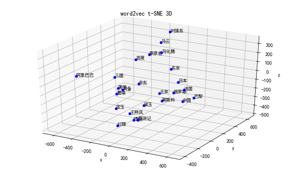

```python
plot_tsne_3D(word_vectors, words_list)
```

## 补充

### [词向量可视化](https://zhuanlan.zhihu.com/p/33786815)

[Keras 模型中使用预训练的 gensim 词向量和可视化](https://eliyar.biz/using-pre-trained-gensim-word2vector-in-a-keras-model-and-visualizing/)  
[TensorBoard：可视化学习](https://www.tensorflow.org/programmers_guide/summaries_and_tensorboard)  
[Logging MXNet data for visualization in TensorBoard](https://github.com/awslabs/mxboard)  
[mxboard-demo](https://github.com/reminisce/mxboard-demo#visualizing-convnet-codes-as-embeddings)  
word2vec-graph

### 训练 Word2Vec

[通过搜狗新闻语料用word2Vec训练中文模型](https://www.jianshu.com/p/6d542ff65b1e)  
[基于gensim的Wiki百科中文word2vec训练](https://www.jianshu.com/p/ca16a5cda72c) [基于 Gensim 的 Word2Vec 实践](https://segmentfault.com/a/1190000008173404)

## 训练 Word2Vec

[Gensim - models.word2vec – Deep learning with word2vec](https://radimrehurek.com/gensim/models/word2vec.html)

### 预处理

**读取数据**

```python
import pandas as pd
import jieba
df12 = pd.read_csv('JianShuJiaoYou-All-Data.csv', encoding='utf-8')
content = df12.Artical_Content.values.tolist()

stopwords1 = [line.rstrip() for line in open('./Stopwords/中文停用词库.txt', 'r', encoding='utf-8')]
stopwords2 = [line.rstrip() for line in open('./Stopwords/哈工大停用词表.txt', 'r', encoding='utf-8')]
stopwords3 = [line.rstrip() for line in open('./Stopwords/四川大学机器智能实验室停用词库.txt', 'r', encoding='utf-8')]
stopwords = stopwords1 + stopwords2 + stopwords3
print(stopwords[10:20])

sentences = []
for line in content:
    try:
        segs = jieba.lcut(line)
        segs = filter(lambda x:len(x)>1, segs)
        segs = filter(lambda x:x not in stopwords, segs)
        # sentences.append(segs)
        sentences.append(list(segs))
    except Exception as e:
        print(line)
        continue
```

```
['9', '?', '_', '“', '”', '、', '。', '《', '》', '一']
```

**建模**

```python
import multiprocessing
from gensim.models import Word2Vec

model_csv = Word2Vec(sentences, min_count=20, sg=0, workers=multiprocessing.cpu_count())
model_csv.wv.most_similar(['简书'], topn=15)
```

```
[('平台', 0.9652707576751709),
 ('书上', 0.9172982573509216),
 ('签约', 0.9150270223617554),
 ('一位', 0.9021144509315491),
 ('简书里', 0.8962454199790955),
 ('加入', 0.8832234740257263),
 ('这篇', 0.8713905811309814),
 ('篇文章', 0.868287205696106),
 ('注册', 0.8606014847755432),
 ('下载', 0.8584223389625549),
 ('发表', 0.8566778898239136),
 ('推荐', 0.8563597202301025),
 ('读者', 0.8507974147796631),
 ('更新', 0.8505660891532898),
 ('大神', 0.8467515707015991)]
```

### 获取关键词的词向量

```python
import numpy as np

textrank4 = [('时候', 1.0), ('简书', 0.9286492277441794), ('朋友', 0.5604058706337074), ('文章', 0.5119472310224017), ('大家', 0.4435913680744001), ('交友', 0.4205067493937958), ('时间', 0.41736915018165616), ('大学', 0.4169278527224929), ('文字', 0.3963519612404718), ('故事', 0.3672191429321304), ('简友', 0.36709289668920975), ('感觉', 0.35411529061992564), ('老师', 0.3370038815808798), ('我会', 0.3101842556848121), ('爱情', 0.30825849431508767), ('学校', 0.30662500150442545), ('专题', 0.299080272407531), ('世界', 0.29379547283412577), ('职业', 0.2929284746124939), ('人生', 0.28212943657396355), ('投稿', 0.2754165402924258), ('电影', 0.27084013365232207), ('地方', 0.2655583424411362), ('有点', 0.2649051503775889), ('作者', 0.2613174610146301), ('城市', 0.24550688949342553), ('东西', 0.24348419679662475), ('同学', 0.23841170153880684), ('学生', 0.23443411939906686), ('树洞', 0.22549473477170823), ('地点', 0.20712676215703693), ('经历', 0.20608419109008802), ('事情', 0.20498750024362533), ('照片', 0.19831572966462627), ('读书', 0.19723125271747666), ('孩子', 0.19590875756904957), ('问题', 0.1950987501036272), ('专业', 0.1941308404236128), ('毕业', 0.1939784822425237), ('性格', 0.19163281061909265), ('姑娘', 0.1872873953553624), ('北京', 0.18711323544187944), ('校园', 0.18108048763244047), ('交流', 0.17479075171098915), ('小说', 0.1744489125132006), ('昵称', 0.17278550504553727), ('女生', 0.16036058073353426), ('上海', 0.1555424366485686), ('摄影', 0.15437243518224159), ('手机', 0.15001221722155475), ('内心', 0.1498803581932257), ('女孩', 0.1420033316012718), ('中国', 0.14108442073599178),('个人', 0.1396337218826528), ('梦想', 0.1383044717425788), ('星座', 0.13691646574539962), ('父母', 0.13591526696869471), ('名字', 0.13546880519692672), ('男生', 0.1351786737272621), ('音乐', 0.13261750151949542), ('青春', 0.13248117530194672), ('年龄', 0.130218163157079), ('家乡', 0.13015312193689477), ('时光', 0.13011176820620574), ('感情', 0.1236245579291077), ('文学', 0.12219078262090802), ('对方', 0.12127366033704323), ('文化', 0.11949249561938287), ('样子', 0.11933270991118002), ('无法', 0.1160694694481027), ('公司', 0.11393609119202278), ('美丽', 0.11346685727914173), ('素材', 0.11260943797689577), ('文艺', 0.11214607732254779), ('社会', 0.11129040508307939), ('记录', 0.11026878566857379), ('哥哥', 0.10647851040624062), ('灵魂', 0.10550214627239118), ('妈妈', 0.10548042030212171), ('单身', 0.10441633340095628), ('美食', 0.10353294903694504), ('日子', 0.10329149448243866), ('家庭', 0.10318263761013736), ('回家', 0.1031507187785797), ('情书', 0.1016292107348871), ('平台', 0.10033539429082454), ('心情', 0.09941978518090189), ('关系', 0.09936235890745156), ('结果', 0.09921749317216594),('性别', 0.09774431497611233), ('原因', 0.09718288385610466), ('能力', 0.09654204453652812), ('眼睛', 0.09500589276815452), ('方面', 0.09344377276647843), ('咖啡', 0.09308300266400003), ('编辑', 0.09261718849186786), ('唱歌', 0.09259885920867623), ('游戏', 0.0925207868456076), ('评论', 0.09215243824369766), ('小时', 0.0902800089476482), ('现实', 0.08990953691346824), ('画画', 0.08934110877054963), ('声音', 0.08825729924787094), ('小时候', 0.08822176014621334), ('历史', 0.08809857794598301), ('姐姐', 0.08792537493674343), ('情感', 0.08792207096319951), ('理想', 0.08771235173748758), ('方式', 0.08724940148031382), ('跑步', 0.0869304779180642), ('男人', 0.08633249891743755), ('想象', 0.0861780084107231), ('凡人', 0.08472430195238598), ('图书馆', 0.08379652187244854), ('内容', 0.08369840352278336), ('时代', 0.08357829612162883), ('见面', 0.08268384574649262), ('大赛', 0.08214344765516189), ('身体', 0.08072503997603832), ('衣服', 0.08013296305558819), ('宿舍', 0.08007039566913592), ('嘉宾', 0.07976389314399422), ('女人', 0.07880340512675509), ('总会', 0.07857359333429292), ('公众', 0.07788072785387959), ('风景', 0.07728373398381409), ('学会', 0.07620797483354486), ('陌生', 0.07554458794593061), ('兴趣', 0.07547524059813622), ('基本', 0.07511660271898915), ('学历', 0.07466066268179476), ('精神', 0.07320609402769758), ('成都', 0.07209550659981127), ('先生', 0.07159410516959858), ('好友', 0.07086173707576542), ('校友', 0.0706236976907227), ('习惯', 0.07036667551986377), ('作品', 0.070225897406981), ('教室', 0.07003924798119593), ('艺术', 0.06953458309960944), ('思想', 0.0695151939250779), ('小学', 0.06878776810395813), ('男朋友', 0.06834683897785196), ('线下', 0.06822167039165473), ('联系', 0.06778415729076948), ('社群', 0.06652535382709325), ('武汉', 0.06640180937345067), ('家人', 0.06622742726001085), ('信息', 0.06599559275698536), ('模样', 0.06583275269266327), ('礼物', 0.0654869832982491), ('世间', 0.06544861340496239), ('长大', 0.0651926779186585), ('味道', 0.06507163406682973), ('陌生人', 0.06479192726379385), ('广州', 0.06474913624114682), ('父亲', 0.06443876952462216), ('朋友圈', 0.06358797412193237), ('印象', 0.06348968764072996), ('机会', 0.06305097363139245), ('女性', 0.06259522220057501), ('体重', 0.0622019187477037), ('空间', 0.06146234707401598), ('妹子', 0.06075048517571015), ('玫瑰', 0.060599050346646754), ('记忆', 0.06048688933848081), ('婚姻', 0.06007535032378195), ('人们', 0.06002079239154834), ('重庆', 0.05990200188329886), ('热情', 0.059740919682304196), ('杭州', 0.05951863279283471), ('计划', 0.05848635158026506),('情况', 0.05841156001822765), ('读者', 0.05837196888897777), ('男孩', 0.05832264782248742), ('西安', 0.056978015411144875), ('小伙伴', 0.05650381835027717), ('励志', 0.05624269204664784), ('会员', 0.0561974154919452), ('少女', 0.055158999699954095), ('火车', 0.05452389418507691), ('体验', 0.054505113215031285), ('深圳', 0.05447157828333691), ('幻想', 0.05444464616366215), ('人物', 0.05416593678569893), ('陪伴', 0.054031257633965254), ('情绪', 0.05394182531653573), ('人家', 0.05381915110012886), ('意义', 0.0536712199874301), ('室友', 0.0536620359988344), ('大学生', 0.053617265404430264), ('国家', 0.05351253423804434), ('女孩子', 0.05346623748374888), ('山东', 0.05332188488298575), ('状态', 0.053309158881276124), ('程序员', 0.053049965125002145), ('天空', 0.05282982480780842), ('链接', 0.052685644517004276), ('思维', 0.05252223966685003), ('标准', 0.05250929737688007)]

words_list = []
word_vectors = []
for word,_ in textrank4:
    try:
        result = model_csv.wv.most_similar(positive=[word],topn=15)
        print("关键词: {}".format(word))
        print(result)
        print("+++++++++++++++++++++++++++++++++++")
        w2v = model_csv.wv[word]
        words_list.append(word)
        word_vectors.append(w2v)
        #for v in w2v:
        #    print(v[0],v[1])
    except:
        print("No word: {}".format(word))

word_vectors = np.array(word_vectors)
```

```
No word: 时候
关键词: 简书
[('平台', 0.9652707576751709), ('书上', 0.9172982573509216), ('签约', 0.9150270223617554), ('一位', 0.9021144509315491), ('简书里', 0.8962454199790955), ('加入', 0.8832234740257263), ('这篇', 0.8713905811309814), ('篇文章', 0.868287205696106), ('注册', 0.8606014847755432), ('下载', 0.8584223389625549), ('发表', 0.856677889…
+++++++++++++++++++++++++++++++++++
关键词: 朋友
[('认识', 0.8872804641723633), ('志同道合', 0.8313576579093933), ('一群', 0.7651041746139526), ('交个', 0.7520003318786621), ('交到', 0.7418329119682312), ('高兴', 0.7363221645355225), ('交朋友', 0.7341246604919434), ('陌生人', 0.7296097874641418), ('结交', 0.7050282955169678), ('小伙伴', 0.6884372234344482), ('几个', 0.68163…
+++++++++++++++++++++++++++++++++++
关键词: 文章
[('一篇', 0.9759280681610107), ('写出', 0.8813140392303467), ('作者', 0.8808531761169434), ('书上', 0.8800405263900757), ('大神', 0.8762398958206177), ('读者', 0.8756917715072632), ('第一篇', 0.8589834570884705), ('几篇', 0.8578100800514221), ('篇文章', 0.8577076196670532), ('评论', 0.855923056602478), ('点赞', 0.851974010…
+++++++++++++++++++++++++++++++++++
No word: 大家
关键词: 交友
[('宣言', 0.9217804670333862), ('创作', 0.8966624736785889), ('目的', 0.8619266748428345), ('平台', 0.8424855470657349), ('首款', 0.8421673774719238), ('会员', 0.8354177474975586), ('加入', 0.8323907852172852), ('材质', 0.8291328549385071), ('大赛', 0.8248733282089233), ('周边', 0.8197598457336426), ('专题', 0.8186293840…
+++++++++++++++++++++++++++++++++++
关键词: 时间
[('每天', 0.8179802894592285), ('完成', 0.7881126403808594), ('一年', 0.7735611200332642), ('计划', 0.7492579817771912), ('小时', 0.7361494302749634), ('考试', 0.7348204851150513), ('考研', 0.7326006889343262), ('上班', 0.7322832345962524), ('一个月', 0.7090473175048828), ('忙碌', 0.7086591124534607), ('学习', 0.701473593…
+++++++++++++++++++++++++++++++++++
关键词: 大学
[('高中', 0.8913721442222595), ('毕业', 0.866524338722229), ('四年', 0.8638687133789062), ('初中', 0.8525798320770264), ('三年', 0.8472774028778076), ('高考', 0.830559492111206), ('考上', 0.826050341129303), ('两年', 0.818995475769043), ('学校', 0.7926006317138672), ('一年', 0.789280354976654), ('实习', 0.77618408203125)…
+++++++++++++++++++++++++++++++++++
关键词: 文字
[('情感', 0.9195806384086609), ('记录', 0.8736156821250916), ('写出', 0.8455187678337097), ('吸引', 0.8192799091339111), ('表达', 0.8184493780136108), ('文笔', 0.810120701789856), ('鸡汤', 0.8027776479721069), ('作家', 0.7983332872390747), ('阅读', 0.7858200669288635), ('写作', 0.7839778661727905), ('喜爱', 0.77832019329…
+++++++++++++++++++++++++++++++++++
关键词: 故事
[('记录', 0.7965211868286133), ('分享', 0.7496322393417358), ('文字', 0.7458515167236328), ('写下', 0.7337595224380493), ('写出', 0.7141837477684021), ('写成', 0.7135831117630005), ('情感', 0.7085205316543579), ('感悟', 0.7056292295455933), ('讲述', 0.6998004913330078), ('励志', 0.6994560956954956), ('倾听', 0.6826714873…
+++++++++++++++++++++++++++++++++++
关键词: 简友
[('热评', 0.9722644090652466), ('欢迎', 0.9521213173866272), ('私信', 0.9466228485107422), ('进群', 0.9103646874427795), ('留言', 0.9090462923049927), ('加群', 0.9028599858283997), ('倾诉', 0.8939998149871826), ('添加', 0.8918091654777527), ('互动', 0.8907224535942078), ('打赏', 0.8879890441894531), ('好友', 0.8861901760…
+++++++++++++++++++++++++++++++++++
关键词: 感觉
[('好像', 0.8716455101966858), ('有时候', 0.8577699661254883), ('那种', 0.8532243967056274), ('总是', 0.8287171721458435), ('不好', 0.824917197227478), ('说话', 0.82464599609375), ('是因为', 0.8164138793945312), ('心情', 0.8077576160430908), ('以前', 0.8017545938491821), ('情绪', 0.7977200746536255), ('真的', 0.79373246431…
+++++++++++++++++++++++++++++++++++
关键词: 老师
[('语文', 0.8197598457336426), ('同学', 0.7662110328674316), ('考试', 0.7449801564216614), ('学校', 0.7397114038467407), ('作文', 0.7394987940788269), ('当时', 0.7331591844558716), ('小学', 0.7177181243896484), ('几天', 0.7131802439689636), ('一段时间', 0.7021613121032715), ('三个', 0.7013662457466125), ('作业', 0.68746262…
+++++++++++++++++++++++++++++++++++
关键词: 我会
[('一定', 0.9040706157684326), ('身边', 0.8560770750045776), ('没关系', 0.8439070582389832), ('好好', 0.8299530148506165), ('一天', 0.8279651403427124), ('我能', 0.8221837282180786), ('照顾', 0.8133571147918701), ('总会', 0.810866117477417), ('足够', 0.8090741634368896), ('难过', 0.8030511140823364), ('担心', 0.7954168915…
+++++++++++++++++++++++++++++++++++
关键词: 爱情
[('友情', 0.91872239112854), ('感情', 0.8881085515022278), ('一生', 0.8835499286651611), ('现实', 0.8818110227584839), ('世间', 0.8662703037261963), ('拥有', 0.8634309768676758), ('渴望', 0.8627880811691284), ('永远', 0.861745297908783), ('无法', 0.8546895980834961), ('懂得', 0.8437632918357849), ('婚姻', 0.8401567935943…
```

[output cut: 529 more lines]

```
关键词: 程序员
[('产品', 0.9193503856658936), ('每月', 0.9057344794273376), ('一对一', 0.8979515433311462), ('相亲', 0.8974717259407043), ('大冒险', 0.8969310522079468), ('真心话', 0.8908487558364868), ('女性', 0.890363335609436), ('送礼物', 0.8898139595985413), ('给出', 0.8876290917396545), ('申请表', 0.8869567513465881), ('符合', 0.885178…
+++++++++++++++++++++++++++++++++++
关键词: 天空
[('夜晚', 0.9742198586463928), ('画面', 0.9659431576728821), ('午后', 0.9630041122436523), ('整个', 0.9578946828842163), ('空气', 0.9571669101715088), ('大海', 0.9540855884552002), ('星星', 0.9537728428840637), ('清晨', 0.9531463384628296), ('微风', 0.9512579441070557), ('外面', 0.9468154907226562), ('穿着', 0.9431188702…
+++++++++++++++++++++++++++++++++++
关键词: 链接
[('本文', 0.9839658141136169), ('留言', 0.9806423187255859), ('打赏', 0.979375958442688), ('QQ', 0.9761103391647339), ('收录', 0.9744284749031067), ('简信', 0.9744261503219604), ('赞赏', 0.9735296964645386), ('人数', 0.971328616142273), ('格式', 0.9712511301040649), ('点评', 0.9712299704551697), ('点开', 0.967613935470…
+++++++++++++++++++++++++++++++++++
关键词: 思维
[('天赋', 0.9735429286956787), ('患者', 0.9716339111328125), ('语言', 0.9715416431427002), ('深度', 0.9676028490066528), ('领域', 0.9665578603744507), ('技能', 0.9653335213661194), ('氛围', 0.9642869830131531), ('内涵', 0.9635614156723022), ('谈不上', 0.9605081081390381), ('随性', 0.9604930877685547), ('喜好', 0.960051774…
+++++++++++++++++++++++++++++++++++
关键词: 标准
[('仙女', 0.9797438383102417), ('妹纸', 0.960526168346405), ('94', 0.9600745439529419), ('巨蟹座', 0.9580286741256714), ('93', 0.9559173583984375), ('95', 0.9553012251853943), ('程序', 0.9511508941650391), ('大叔', 0.9496055841445923), ('关键字', 0.9465398788452148), ('处女座', 0.9454711675643921), ('98', 0.94403922…
+++++++++++++++++++++++++++++++++++
```

```python
#print(words_list)
print("Total words:", len(words_list), '\tWord Embedding shapes:', word_vectors.shape)
```

```
Total words: 192 	Word Embedding shapes: (192, 100)
```

### 查询相近的词语

```python
model_csv.wv.most_similar(['简书'], topn=15)
```

```
[('平台', 0.9652707576751709),
 ('书上', 0.9172982573509216),
 ('签约', 0.9150270223617554),
 ('一位', 0.9021144509315491),
 ('简书里', 0.8962454199790955),
 ('加入', 0.8832234740257263),
 ('这篇', 0.8713905811309814),
 ('篇文章', 0.868287205696106),
 ('注册', 0.8606014847755432),
 ('下载', 0.8584223389625549),
 ('发表', 0.8566778898239136),
 ('推荐', 0.8563597202301025),
 ('读者', 0.8507974147796631),
 ('更新', 0.8505660891532898),
 ('大神', 0.8467515707015991)]
```

```python
model_csv.wv.most_similar(['交友'], topn=15)
```

```
[('宣言', 0.9217804670333862),
 ('创作', 0.8966624736785889),
 ('目的', 0.8619266748428345),
 ('平台', 0.8424855470657349),
 ('首款', 0.8421673774719238),
 ('会员', 0.8354177474975586),
 ('加入', 0.8323907852172852),
 ('材质', 0.8291328549385071),
 ('大赛', 0.8248733282089233),
 ('周边', 0.8197598457336426),
 ('专题', 0.8186293840408325),
 ('社群', 0.8180769681930542),
 ('一位', 0.8163666725158691),
 ('用户', 0.815901517868042),
 ('简书', 0.8137665390968323)]
```

```python
# 保存模型
# model.save(outp1)
# model.wv.save_word2vec_format(outp2, binary=False)
```

### 2维 t-SNE 可视化词向量

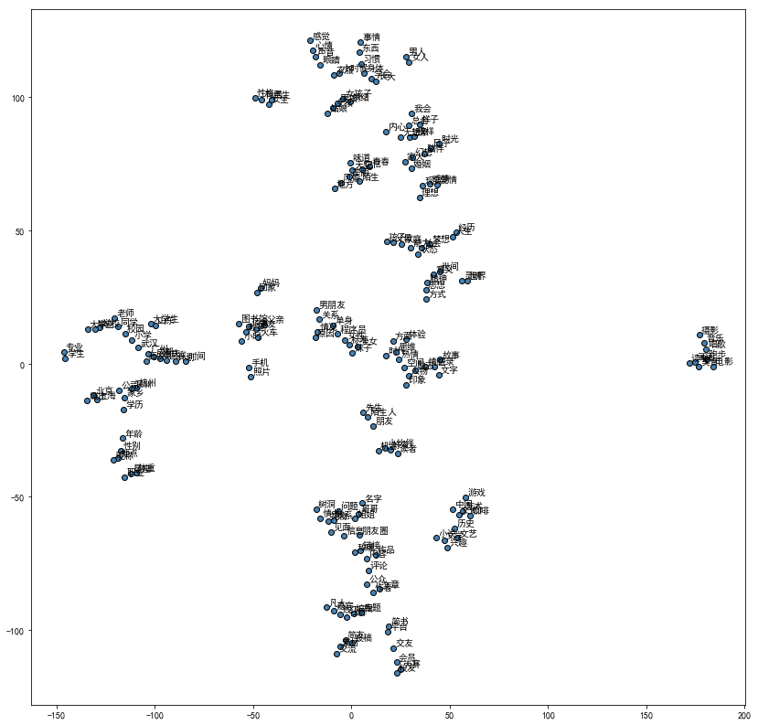

```python
plot_tsne_2D(word_vectors, words_list)
```

### 3维 t-SNE 可视化词向量

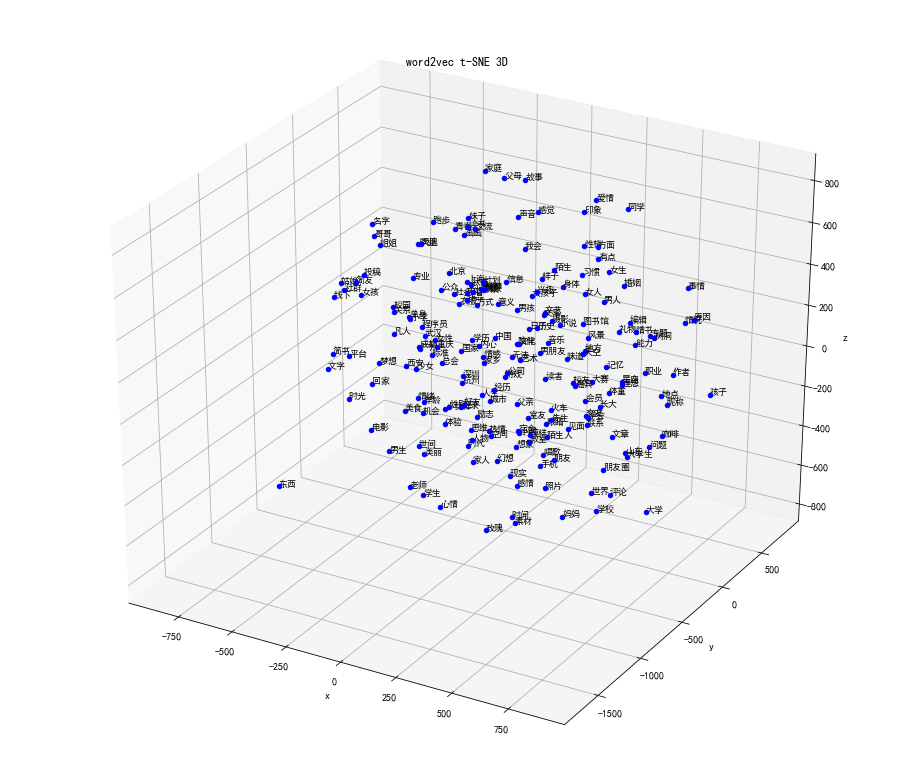

```python
plot_tsne_3D(word_vectors, words_list)
```

```python
%config InlineBackend.figure_format='svg'
plot_tsne_2D(word_vectors, words_list)
```

[figure not shown]

```python
%config InlineBackend.figure_format='svg'
plot_tsne_3D(word_vectors, words_list)
```

[figure not shown]

本文先更新到此，主要涉及关键词的抽取、Word2Vec词向量的尝试和探索。后续LDA主题模型及主题的可视化、文章照片爬取、人脸识别及颜值打分和照片墙等等更新后也会开源在[**GitHub - DesertsX / JianShuJiaoYou**](https://github.com/DesertsX/JianShuJiaoYou)，欢迎star与指正。

系列文章：  
[乱炖数据之2700余篇“简书交友”专题文章数据的花式玩法](https://zhuanlan.zhihu.com/p/37618589)  
[乱炖“简书交友”数据之代码（1）](https://zhuanlan.zhihu.com/p/38058243)

**PS：预告下，即将开启“Kaggle Kernel 学习系列”，[GitHub - DesertsX / Kaggle-Kernel-Learning](https://github.com/DesertsX/Kaggle-Kernel-Learning)**，欢迎star。

**PPS：欢迎关注公众号：牛衣古柳（ID：Deserts-X），以及欢迎加QQ群：Python交友娱乐会所（613176398）哈。娱乐会所，没有嫩模。**